# Statistical Inference Course Project Question 2

Thomas Tong

Saturday, November 22, 2014

Load qqplot2 package, psych (for describe function) and datasets, then observe the columns in ToothGrowth datasets.

```r
library("ggplot2")
library("psych")
library("datasets")
str(ToothGrowth)
```

```
## 'data.frame':    60 obs. of  3 variables:
##  $ len : num  4.2 11.5 7.3 5.8 6.4 10 11.2 11.2 5.2 7 ...
##  $ supp: Factor w/ 2 levels "OJ","VC": 2 2 2 2 2 2 2 2 2 2 ...
##  $ dose: num  0.5 0.5 0.5 0.5 0.5 0.5 0.5 0.5 0.5 0.5 ...
```

`supp` columns indicates the supplement taken, values are `OJ` (orange juice) and `VC` (vitamin c).

`dose` column indicates the dose amount taken, values are `0.5`, `1.0` and `2.0`.

```r
unique(ToothGrowth$dose)
```

```
## [1] 0.5 1.0 2.0
```

Stats for `len` column, the length of tooth, which is the outcome data we want to study.

```r
describe(ToothGrowth$len)
```

```
##   vars  n  mean   sd median trimmed  mad min  max range  skew kurtosis
## 1    1 60 18.81 7.65  19.25   18.95 9.04 4.2 33.9  29.7 -0.14    -1.04
##     se
## 1 0.99
```

We can do some basic exploratory data analyses first. The following plot shows the tooth length distribution on different supplement and dose amount.

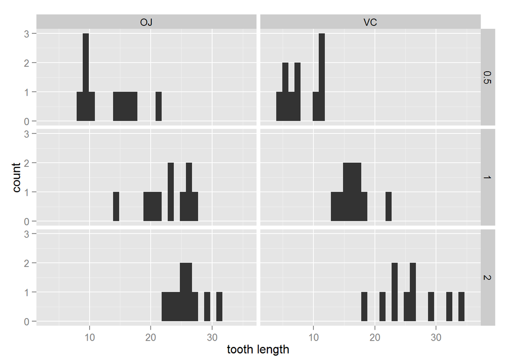

```r
ggplot(ToothGrowth, aes(x = len)) + geom_histogram() + facet_grid(dose ~ supp) + xlab("tooth length")
```

The following plot shows a trend line of tooth length when the dose amount of different supplement changes.

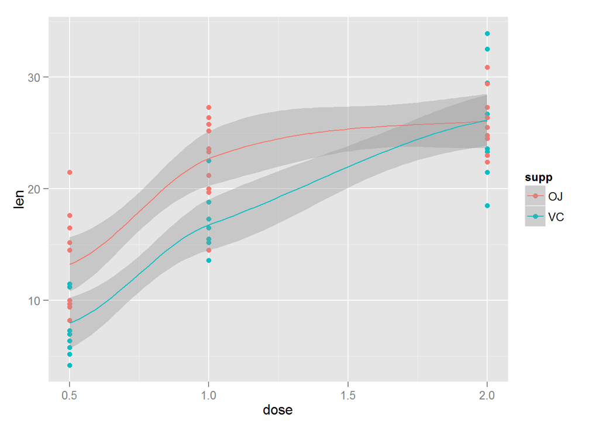

```r
qplot(dose, len, data = ToothGrowth, color = supp) + geom_smooth()
```

From the chart we can see that orange juice has a larger effect on tooth growth. Vitamin C has a smaller effect compared with orange juice but the effect start to be greater when dose is increaing from `1.0` to `2.0`. Both supplement offers the same effect when dose reaches `2.0`.

We can confirm this observation by doing T-tests on the data set. The following codes first seperates the data into different subset of supplements and doses, then use T-tests function on the data subsets. By checking the p-values and confidence intevals, the aforesaid observations are confirmed.

Codes for filtering data:

```r
oj05 <- ToothGrowth[((ToothGrowth$supp=='OJ')&(ToothGrowth$dose==0.5)),'len']
oj10 <- ToothGrowth[((ToothGrowth$supp=='OJ')&(ToothGrowth$dose==1.0)),'len']
oj20 <- ToothGrowth[((ToothGrowth$supp=='OJ')&(ToothGrowth$dose==2.0)),'len']
vc05 <- ToothGrowth[((ToothGrowth$supp=='VC')&(ToothGrowth$dose==0.5)),'len']
vc10 <- ToothGrowth[((ToothGrowth$supp=='VC')&(ToothGrowth$dose==1.0)),'len']
vc20 <- ToothGrowth[((ToothGrowth$supp=='VC')&(ToothGrowth$dose==2.0)),'len']
```

Codes for T-tests:

```r
t.test(oj05, vc05)
```

```
##
##  Welch Two Sample t-test
##
## data:  oj05 and vc05
## t = 3.1697, df = 14.969, p-value = 0.006359
## alternative hypothesis: true difference in means is not equal to 0
## 95 percent confidence interval:
##  1.719057 8.780943
## sample estimates:
## mean of x mean of y
##     13.23      7.98
```

```r
t.test(oj10, vc10)
```

```
##
##  Welch Two Sample t-test
##
## data:  oj10 and vc10
## t = 4.0328, df = 15.358, p-value = 0.001038
## alternative hypothesis: true difference in means is not equal to 0
## 95 percent confidence interval:
##  2.802148 9.057852
## sample estimates:
## mean of x mean of y
##     22.70     16.77
```

```r
t.test(oj20, vc20)
```

```
##
##  Welch Two Sample t-test
##
## data:  oj20 and vc20
## t = -0.0461, df = 14.04, p-value = 0.9639
## alternative hypothesis: true difference in means is not equal to 0
## 95 percent confidence interval:
##  -3.79807  3.63807
## sample estimates:
## mean of x mean of y
##     26.06     26.14
```

```r
t.test(oj05, oj10)
```

```
##
##  Welch Two Sample t-test
##
## data:  oj05 and oj10
## t = -5.0486, df = 17.698, p-value = 8.785e-05
## alternative hypothesis: true difference in means is not equal to 0
## 95 percent confidence interval:
##  -13.415634  -5.524366
## sample estimates:
## mean of x mean of y
##     13.23     22.70
```

```r
t.test(oj10, oj20)
```

```
##
##  Welch Two Sample t-test
##
## data:  oj10 and oj20
## t = -2.2478, df = 15.842, p-value = 0.0392
## alternative hypothesis: true difference in means is not equal to 0
## 95 percent confidence interval:
##  -6.5314425 -0.1885575
## sample estimates:
## mean of x mean of y
##     22.70     26.06
```

```r
t.test(vc05, vc10)
```

```
##
##  Welch Two Sample t-test
##
## data:  vc05 and vc10
## t = -7.4634, df = 17.862, p-value = 6.811e-07
## alternative hypothesis: true difference in means is not equal to 0
## 95 percent confidence interval:
##  -11.265712  -6.314288
## sample estimates:
## mean of x mean of y
##      7.98     16.77
```

```r
t.test(vc10, vc20)
```

```
##
##  Welch Two Sample t-test
##
## data:  vc10 and vc20
## t = -5.4698, df = 13.6, p-value = 9.156e-05
## alternative hypothesis: true difference in means is not equal to 0
## 95 percent confidence interval:
##  -13.054267  -5.685733
## sample estimates:
## mean of x mean of y
##     16.77     26.14
```